# Self-Driving Car Engineer Nanodegree

## Project: **Finding Lane Lines on the Road**

In this project, you will use the tools you learned about in the lesson to identify lane lines on the road. You can develop your pipeline on a series of individual images, and later apply the result to a video stream (really just a series of images). Check out the video clip "raw-lines-example.mp4" (also contained in this repository) to see what the output should look like after using the helper functions below.

Once you have a result that looks roughly like "raw-lines-example.mp4", you'll need to get creative and try to average and/or extrapolate the line segments you've detected to map out the full extent of the lane lines. You can see an example of the result you're going for in the video "P1_example.mp4". Ultimately, you would like to draw just one line for the left side of the lane, and one for the right.

In addition to implementing code, there is a brief writeup to complete. The writeup should be completed in a separate file, which can be either a markdown file or a pdf document. There is a [write up template](https://github.com/udacity/CarND-LaneLines-P1/blob/master/writeup_template.md) that can be used to guide the writing process. Completing both the code in the Ipython notebook and the writeup template will cover all of the [rubric points](https://review.udacity.com/#!/rubrics/322/view) for this project.

Let's have a look at our first image called 'test_images/solidWhiteRight.jpg'. Run the 2 cells below (hit Shift-Enter or the "play" button above) to display the image.

**Note: If, at any point, you encounter frozen display windows or other confounding issues, you can always start again with a clean slate by going to the "Kernel" menu above and selecting "Restart & Clear Output".**

**The tools you have are color selection, region of interest selection, grayscaling, Gaussian smoothing, Canny Edge Detection and Hough Tranform line detection. You are also free to explore and try other techniques that were not presented in the lesson. Your goal is piece together a pipeline to detect the line segments in the image, then average/extrapolate them and draw them onto the image for display (as below). Once you have a working pipeline, try it out on the video stream below.**

[figure not shown]

Your output should look something like this (above) after detecting line segments using the helper functions below

[figure not shown]

Your goal is to connect/average/extrapolate line segments to get output like this

**Run the cell below to import some packages. If you get an `import error` for a package you've already installed, try changing your kernel (select the Kernel menu above --> Change Kernel). Still have problems? Try relaunching Jupyter Notebook from the terminal prompt. Also, consult the forums for more troubleshooting tips.**

## Import Packages

```python
#importing some useful packages
import matplotlib.pyplot as plt
import matplotlib.image as mpimg
import numpy as np
import cv2
import os
import math
import glob
%matplotlib inline
```

## Read in an Image

```
This image is: <class 'numpy.ndarray'> with dimensions: (540, 960, 3)
```

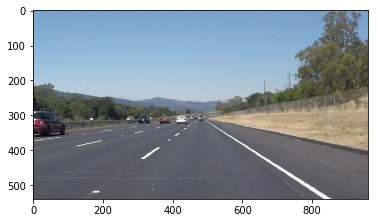

```python
# reading in an image
# Matplotlib use the color channel RBG
image = mpimg.imread('test_images/solidWhiteRight.jpg')

# OpenCV use the color channnel BGR
# image = cv2.imread('test_images/solidWhiteRight.jpg')
# image = cv2.cvtColor(image,cv2.COLOR_BGR2RGB)

#printing out some stats and plotting
print('This image is:', type(image), 'with dimensions:', image.shape)
# if you wanted to show a single color channel image called 'gray', for example, call as plt.imshow(gray, cmap='gray')

plt.imshow(image)
# plt.show() not necessary, because of inline plotting (%matplotlib inline)
```

## Ideas for Lane Detection Pipeline

**Some OpenCV functions (beyond those introduced in the lesson) that might be useful for this project are:**

`cv2.inRange()` for color selection  
`cv2.fillPoly()` for regions selection  
`cv2.line()` to draw lines on an image given endpoints  
`cv2.addWeighted()` to coadd / overlay two images `cv2.cvtColor()` to grayscale or change color `cv2.imwrite()` to output images to file  
`cv2.bitwise_and()` to apply a mask to an image

**Check out the OpenCV documentation to learn about these and discover even more awesome functionality!**

## Helper Functions

Below are some helper functions to help get you started. They should look familiar from the lesson!

```python
def grayscale(img):
    """Applies the Grayscale transform
    This will return an image with only one color channel
    but NOTE: to see the returned image as grayscale
    (assuming your grayscaled image is called 'gray')
    you should call plt.imshow(gray, cmap='gray')"""
    #return cv2.cvtColor(img, cv2.COLOR_RGB2GRAY)
    # Or use BGR2GRAY if you read an image with cv2.imread()
    return cv2.cvtColor(img, cv2.COLOR_RGB2GRAY)

def canny(img, low_threshold, high_threshold):
    """Applies the Canny transform"""
    return cv2.Canny(img, low_threshold, high_threshold)

def gaussian_blur(img, kernel_size):
    """Applies a Gaussian Noise kernel"""
    return cv2.GaussianBlur(img, (kernel_size, kernel_size), 0)

def region_of_interest(img, vertices):
    """
    Applies an image mask.

    Only keeps the region of the image defined by the polygon
    formed from `vertices`. The rest of the image is set to black.
    """
    #defining a blank mask to start with
    mask = np.zeros_like(img)

    #defining a 3 channel or 1 channel color to fill the mask with depending on the input image
    if len(img.shape) > 2:
        channel_count = img.shape[2]  # i.e. 3 or 4 depending on your image
        ignore_mask_color = (255,) * channel_count
    else:
        ignore_mask_color = 255

    #filling pixels inside the polygon defined by "vertices" with the fill color
    cv2.fillPoly(mask, vertices, ignore_mask_color)

    #returning the image only where mask pixels are nonzero
    masked_image = cv2.bitwise_and(img, mask)
    return masked_image

g_x1_left_prior = 0
g_x2_left_prior = 0
g_x1_right_prior = 0
g_x2_right_prior = 0

def draw_line(img, x, y, color, thickness, line):
    """
    Performing a linear fit to x and y using np.polyfit.
    Then, using coefficients of the fit to average the position of each of the lines
    and extrapolate to the top and bottom of the lane.
    Finally draws it on the image `img` using `color` and `thickness` for the line.
    """
    global g_x1_left_prior
    global g_x2_left_prior
    global g_x1_right_prior
    global g_x2_right_prior

    tolerance = 50

    if len(x) == 0:
        return

    fit = np.polyfit(x, y, 1)
    max_y = img.shape[0]
    # max_x = img.shape[1]

    # y1 and y2 have static values regarding the image
    y1 = max_y
    y2 = int((max_y / 2)) + 65


    # x1 and x2 have dynamic values with prior values of the image before
    # If the tolerance value of the current image is exceeded, then taking the prior values
    x1_prior = 0
    x2_prior = 0
    if line in 'left':
        x1_prior = g_x1_left_prior
        x2_prior = g_x2_left_prior
    else:
        x1_prior = g_x1_right_prior
        x2_prior = g_x2_right_prior

    x1 = int((y1 - fit[1]) / fit[0])
    if x1_prior==0:
        #print("Init x1_prior if 0 ", x1)
        x1_prior = x1
    elif abs(x1_prior - x1) > tolerance:
        print("x1 is exceed the tolerance value, taking prior value ", x1, x1_prior, abs(x1_prior - x1))
        x1 = x1_prior
    else:
        x1 = int((x1 + x1_prior) / 2)
        #print("average current with prior value and set x1_prior", x1)
        x1_prior = x1

    x2 = int((y2 - fit[1]) / fit[0])
    if x2_prior==0:
        #print("Init x2_prior if 0 ", x2)
        x2_prior = x2
    elif abs(x2_prior - x2) > tolerance:
        print("x2 is exceed the tolerance value, taking prior value ", x2, x2_prior, abs(x2_prior - x2))
        x2 = x2_prior
    else:
        x2 = int((x2 + x2_prior) / 2)
        #print("average current with prior value and set x2_prior", x2)
        x2_prior = x2

    if line in 'left':
        g_x1_left_prior = x1_prior
        g_x2_left_prior = x2_prior
    else:
        g_x1_right_prior = x1_prior
        g_x2_right_prior = x2_prior

    #print(x1, x2)

    cv2.line(img, (x1, y1), (x2, y2), color, thickness)


def draw_lines(img, lines, color, thickness):
    """
    NOTE: this is the function you might want to use as a starting point once you want to
    average/extrapolate the line segments you detect to map out the full
    extent of the lane (going from the result shown in raw-lines-example.mp4
    to that shown in P1_example.mp4).

    Think about things like separating line segments by their
    slope ((y2-y1)/(x2-x1)) to decide which segments are part of the left
    line vs. the right line.  Then, you can average the position of each of
    the lines and extrapolate to the top and bottom of the lane.

    This function draws `lines` with `color` and `thickness`.
    Lines are drawn on the image inplace (mutates the image).
    If you want to make the lines semi-transparent, think about combining
    this function with the weighted_img() function below
    """
    #for line in lines:
        #for x1,y1,x2,y2 in line:
            #cv2.line(img, (x1, y1), (x2, y2), color, thickness)

    left_x = []
    left_y = []
    right_x = []
    right_y = []

    for line in lines:
        for x1,y1,x2,y2 in line:
            # separating line segments by their slope to decide which segments are part of the left line vs.
            # the right line
            slope = (y1 - y2) / (x1 - x2)
            if slope < 0:
                left_x.append(x1)
                left_y.append(y1)
                left_x.append(x2)
                left_y.append(y2)
            else:
                right_x.append(x1)
                right_y.append(y1)
                right_x.append(x2)
                right_y.append(y2)

    draw_line(img, left_x, left_y, color, thickness, "left")
    draw_line(img, right_x, right_y, color, thickness, "right")

def hough_lines(img, rho, theta, threshold, min_line_len, max_line_gap, org=0):
    """
    `img` should be the output of a Canny transform.

    Returns an image with hough lines drawn.
    """
    lines = cv2.HoughLinesP(img, rho, theta, threshold, np.array([]), minLineLength=min_line_len, maxLineGap=max_line_gap)
    line_img = np.zeros((img.shape[0], img.shape[1], 3), dtype=np.uint8)
    color = [255, 0, 0]
    thickness = 12
    if org:
        draw_lines_org(line_img, lines, color, thickness)
    else:
        draw_lines(line_img, lines, color, thickness)
    return line_img

# Python 3 has support for cool math symbols.
def weighted_img(img, initial_img, α=0.8, β=1., γ=0.):
    """
    `img` is the output of the hough_lines(), An image with lines drawn on it.
    Should be a blank image (all black) with lines drawn on it.

    `initial_img` should be the image before any processing.

    The result image is computed as follows:

    initial_img * α + img * β + γ
    NOTE: initial_img and img must be the same shape!
    """
    return cv2.addWeighted(initial_img, α, img, β, γ)
```

## Test Images

Build your pipeline to work on the images in the directory "test_images"  
**You should make sure your pipeline works well on these images before you try the videos.**

```python
def read_images(image_dir):
    """
    Read all images with the extension *.jpg
    Returns an image list[(filename, image_array)]
    """

    image_list = []

    for file in glob.glob(image_dir + "/*.jpg"):
        # Read in the image file
        image = mpimg.imread(file)
        image_name = os.path.basename(file)
        # print(file, image_name)
        image_list.append((image_name, image))

    return image_list

def write_image(image, image_name, image_dir_dest, gray=0, show=0):
    """
    Write an image to destination dir
    If show=1 then the image will be shown
    """

    # Create dir if not exist
    if not os.path.exists(image_dir_dest):
        os.makedirs(image_dir_dest)

    filepath_new = image_dir_dest + "/" +  image_name
    if gray:
        plt.imsave(filepath_new, image, cmap='gray')
        if show:
            plt.figure()
            plt.imshow(image, cmap='gray')
    else:
        plt.imsave(filepath_new, image)
        if show:
            plt.figure()
            plt.imshow(image)
```

## Build a Lane Finding Pipeline

Build the pipeline and run your solution on all test_images. Make copies into the `test_images_output` directory, and you can use the images in your writeup report.

Try tuning the various parameters, especially the low and high Canny thresholds as well as the Hough lines parameters.

## Image Pipeline step 1: Converting images into gray scale

```
Image Pipeline step 1: Converting images into gray scale successfully finished
```

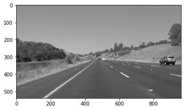

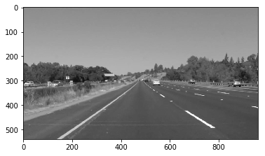

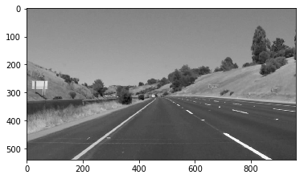

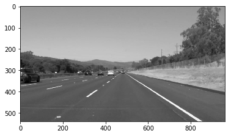

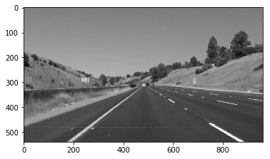

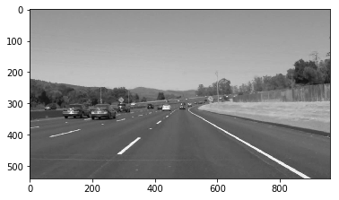

```python
test_images_list = []
test_images_gray_list = []
test_images_list = read_images("test_images")

def image_pipeline_gray(image):
    return grayscale(image)

for image_name, image in test_images_list:
    image_gray = image_pipeline_gray(image)
    write_image(image_gray, image_name, "test_images_gray", 1, 1)
    test_images_gray_list.append((image_name, image_gray))

print("Image Pipeline step 1: Converting images into gray scale successfully finished")
```

## Image Pipeline step 2: Applying Gaussian smoothing

```
Image Pipeline step 2: Applying Gaussian smoothing successfully finished
```

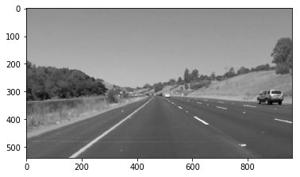

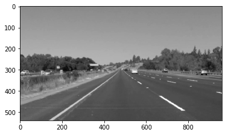

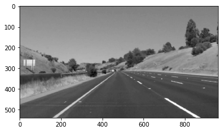

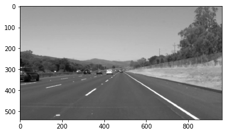

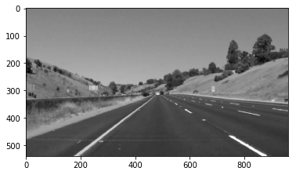

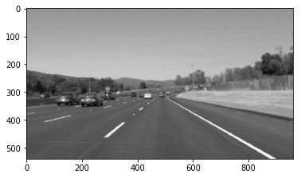

```python
test_images_gaussian_blur_list = []
blur_kernel_size = 5

def image_pipeline_gaussian_blur(image):
    return gaussian_blur(image, blur_kernel_size)

for image_name, image in test_images_gray_list:
    image_gaussian_blur = image_pipeline_gaussian_blur(image)
    write_image(image_gaussian_blur, image_name, "test_images_gaussian_blur", 1, 1)
    test_images_gaussian_blur_list.append((image_name, image_gaussian_blur))

print("Image Pipeline step 2: Applying Gaussian smoothing successfully finished")
```

## Image Pipeline step 3: Applying Canny transform

```
Image Pipeline step 3: Applying Canny transform successfully finished
```

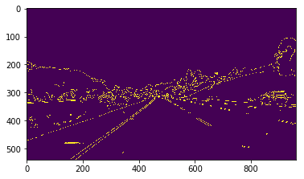

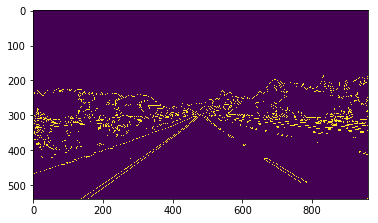

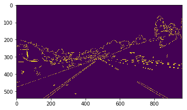

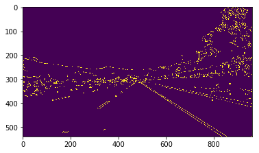

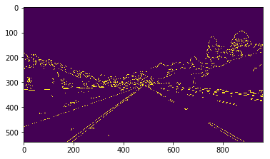

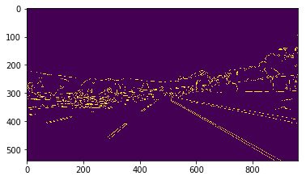

```python
test_images_canny_list = []
canny_low_threshold = 20
canny_high_threshold = 100

def image_pipeline_canny(image):
    return canny(image, canny_low_threshold, canny_high_threshold)

for image_name, image in test_images_gaussian_blur_list:
    image_canny = image_pipeline_canny(image)
    write_image(image_canny, image_name, "test_images_canny", 0, 1)
    test_images_canny_list.append((image_name, image_canny))

print("Image Pipeline step 3: Applying Canny transform successfully finished")
```

## Image Pipeline step 4: Applying Region of Interest

```
Image Pipeline step 4: Applying Region of Interest successfully finished
```

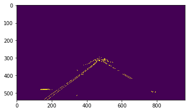

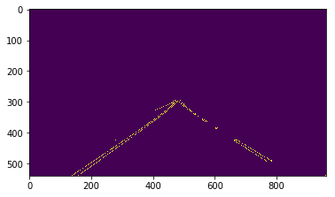

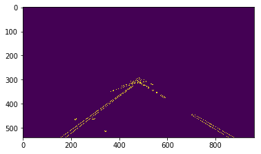

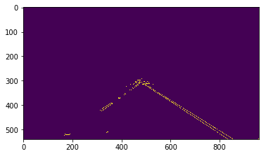

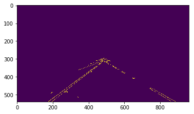

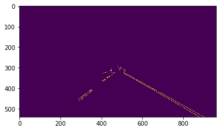

```python
test_images_roi_list = []

def image_pipeline_roi(image):
    y_size = image.shape[0]
    x_size = image.shape[1]
    vertices = np.array([[0, y_size],[x_size / 2, (y_size / 2) + 20], [x_size, y_size]], dtype=np.int32)
    return region_of_interest(image, [vertices])

for image_name, image in test_images_canny_list:
    image_roi = image_pipeline_roi(image)
    write_image(image_roi, image_name, "test_images_roi", 0, 1)
    test_images_roi_list.append((image_name, image_roi))

print("Image Pipeline step 4: Applying Region of Interest successfully finished")
```